FJ

# Feidhelm Joyce

Business & Data Analyst  
Boston, MA

linkedin.com/in/feidhelmjoyce  
github.com/FeidhelmJ

MARKETING ANALYTICS

## Statistical Testing

← Back to Marketing Analytics

```
import seaborn as sns
import matplotlib.pyplot as plt
import pandas as pd
import numpy as np
import scipy.stats as stats
```

```
pd.set_option('display.max_columns', None)
```

```
lobster_run = pd.read_csv('lobster_run.csv')
lobster_run.head()
```

|  | userid | version | sum_gamerounds | retention_1 | retention_7 | user_spend |
| --- | --- | --- | --- | --- | --- | --- |
| 0 | 1 | Gulf of Maine | 3 | False | False | 17.09 |
| 1 | 2 | Gulf of Maine | 38 | True | False | 15.30 |
| 2 | 7 | Gulf of Maine | 0 | False | False | 13.67 |
| 3 | 12 | Gulf of Maine | 0 | False | False | 16.92 |
| 4 | 14 | Gulf of Maine | 39 | True | False | 8.42 |

```
lobster_run_filter = lobster_run[lobster_run['sum_gamerounds'] <= 3000]
```

```
lobster_run_copy = lobster_run.groupby('version')['sum_gamerounds'].sum().sort_values(ascending=False)
lobster_run_copy.head(20)
```

| version | sum_gamerounds |
| --- | --- |
| Gulf of Maine | 2344795 |
| North Atlantic | 2333530 |

**dtype:** int64

```
top_20_gamerounds = lobster_run.sort_values(by='sum_gamerounds', ascending=False).head(20)
display(top_20_gamerounds[['version', 'sum_gamerounds', 'user_spend']])
```

|  | version | sum_gamerounds | user_spend |
| --- | --- | --- | --- |
| 28650 | Gulf of Maine | 49854 | 13.36 |
| 3927 | Gulf of Maine | 2961 | 11.28 |
| 59444 | North Atlantic | 2640 | 15.47 |
| 21685 | Gulf of Maine | 2438 | 12.57 |
| 68948 | North Atlantic | 2294 | 16.28 |
| 23037 | Gulf of Maine | 2251 | 18.00 |
| 43118 | Gulf of Maine | 2156 | 17.68 |
| 63193 | North Atlantic | 2124 | 15.37 |
| 89253 | North Atlantic | 2063 | 18.10 |
| 47967 | North Atlantic | 2015 | 10.41 |
| 332 | Gulf of Maine | 1906 | 19.40 |
| 54051 | North Atlantic | 1816 | 13.68 |
| 13723 | Gulf of Maine | 1714 | 15.55 |
| 6565 | Gulf of Maine | 1705 | 14.16 |
| 50702 | North Atlantic | 1697 | 14.83 |
| 54287 | North Atlantic | 1687 | 15.86 |
| 86860 | North Atlantic | 1667 | 13.50 |
| 61631 | North Atlantic | 1643 | 18.96 |
| 50972 | North Atlantic | 1643 | 17.94 |
| 50103 | North Atlantic | 1573 | 14.85 |

```
lobster_run.describe()
```

|  | userid | sum_gamerounds | user_spend |
| --- | --- | --- | --- |
| count | 90189.000000 | 90189.000000 | 90189.000000 |
| mean | 45095.000000 | 51.872457 | 15.015899 |
| std | 26035.466051 | 195.050858 | 2.747268 |
| min | 1.000000 | 0.000000 | 4.050000 |
| 25% | 22548.000000 | 5.000000 | 13.170000 |
| 50% | 45095.000000 | 16.000000 | 15.010000 |
| 75% | 67642.000000 | 51.000000 | 16.870000 |
| max | 90189.000000 | 49854.000000 | 28.000000 |

**Part I: A/B Testing for User Spending**

A.

Generate a histogram to view the user_spend variable.

Describe your plot in 1-2 sentences

- The bell-shape curve of the plot tells us that user spend appears to be normally distributed. The majority of uses appear to spend somewhere between 12 - 18 dollars. This shows a clear central peak at the mean user spend of roughly 15 dollars, with few users spending less than 10 dollars or more than 20 dollars.

```
sns.histplot(lobster_run['user_spend'], bins = 25, color = "blue")
plt.title("Histogram of User Spend")
plt.xlabel("User Spend")
plt.ylabel("Frequency")
plt.show();
```

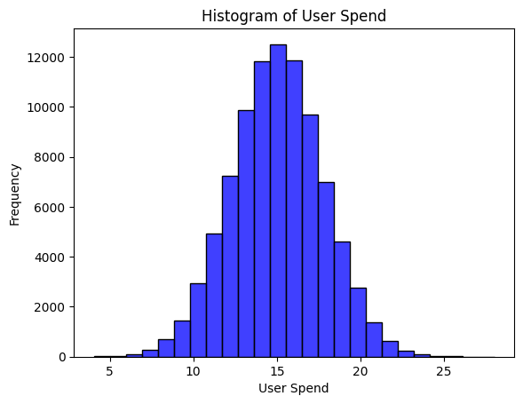

B.

Generate another histogram that depicts user_spend, but this time, use version as a color or hue variable.

Describe your plot in 1-2 sentences.

- The dark blue areas indicate bins where both versions of the app overlap almost perfectly, meaning that they have very similar frequencies & therefore spending distributions.
- There are some bins where we can see that the frequency for users of the North Atlantic version are slightly higher, however this could be attributed this version of the game having roughly 800 more users than the Gulf of Maine, as other descriptive statistics are extremely similar between both versions.

```
sns.histplot(data=lobster_run, x='user_spend', bins = 30, alpha = 0.6, hue='version')
plt.title("Histogram of User Spend by Version")
plt.xlabel("User Spend")
plt.ylabel("Frequency")
plt.show();
```

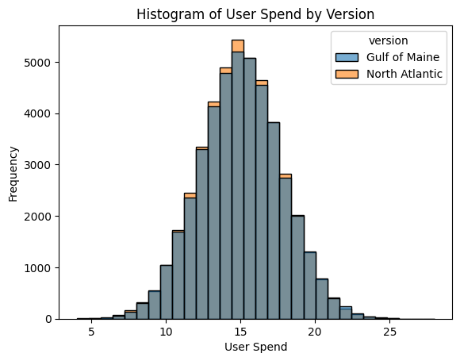

```
lobster_run.groupby('version')['user_spend'].describe()
```

| version | count | mean | std | min | 25% | 50% | 75% | max |
| --- | --- | --- | --- | --- | --- | --- | --- | --- |
| Gulf of Maine | 44700.0 | 15.030548 | 2.750119 | 4.50 | 13.17 | 15.03 | 16.89 | 26.55 |
| North Atlantic | 45489.0 | 15.001504 | 2.744418 | 4.05 | 13.16 | 15.00 | 16.85 | 28.00 |

C.

Conduct a statistical test to check whether the user_spend variable is normally distributed.

a. What is your test’s null hypothesis?

- The user spend variable is normally distributed.

b. Based on the p-value that you see as a result, what can you say about the distribution of this variable?

- p-value: 0.9323
- The p-value is greater than 0.05, so we fail to reject the null hypothesis, therefore the user spend varible is normally distributed. However, since the sample size greatly exceeds the recommended limit for the Shapiro–Wilk test, the p-value may not be fully reliable, but it is safe to assume is would still remain >0.05. For sample sizes this large, a histogram, as shown above, is the best way to assess distribution.

```
from scipy.stats import shapiro

shapiro_stat, shapiro_p_val = shapiro(lobster_run['user_spend'])

print("Shapiro–Wilk statistic:", round(shapiro_stat, 4))
print("p-value:", round(shapiro_p_val, 4))
```

```
Shapiro–Wilk statistic: 1.0
p-value: 0.9323
```

```
/usr/local/lib/python3.12/dist-packages/scipy/stats/_axis_nan_policy.py:579: UserWarning: scipy.stats.shapiro: For N > 5000, computed p-value may not be accurate. Current N is 90189.
  res = hypotest_fun_out(*samples, **kwds)
```

D.

Next, conduct an appropriate statistical test to check whether version has a significant impact on user spending. You can use any alpha value that you prefer to use for the significance threshold.

a. What was your null hypothesis?

- The user spend is the same for both versions of the app.

b. Based on the test, what will you conclude?

- P-value for the test = 0.11241777327832332. Therefore, the p-value is greater than 0.05, so we fail to reject the null hypothesis. This means that there is no statistically significant difference in mean user spending between the Gulf of Maine and North Atlantic game versions.

```
lobster_run.groupby('version').describe()
```

| version | userid count | userid mean | userid std | userid min | userid 25% | userid 50% | userid 75% | userid max | sum_gamerounds count | sum_gamerounds mean | sum_gamerounds std | sum_gamerounds min | sum_gamerounds 25% | sum_gamerounds 50% | sum_gamerounds 75% | sum_gamerounds max | user_spend count | user_spend mean | user_spend std | user_spend min | user_spend 25% | user_spend 50% | user_spend 75% | user_spend max |
| --- | --- | --- | --- | --- | --- | --- | --- | --- | --- | --- | --- | --- | --- | --- | --- | --- | --- | --- | --- | --- | --- | --- | --- | --- |
| Gulf of Maine | 44700.0 | 44996.683826 | 26015.195832 | 1.0 | 22483.75 | 44992.5 | 67515.5 | 90187.0 | 44700.0 | 52.456264 | 256.716423 | 0.0 | 5.0 | 17.0 | 50.0 | 49854.0 | 44700.0 | 15.030548 | 2.750119 | 4.50 | 13.17 | 15.03 | 16.89 | 26.55 |
| North Atlantic | 45489.0 | 45191.610895 | 26055.293884 | 3.0 | 22603.00 | 45199.0 | 67781.0 | 90189.0 | 45489.0 | 51.298776 | 103.294416 | 0.0 | 5.0 | 16.0 | 52.0 | 2640.0 | 45489.0 | 15.001504 | 2.744418 | 4.05 | 13.16 | 15.00 | 16.85 | 28.00 |

```
t_stat, p_val = stats.ttest_ind(
    lobster_run.loc[lobster_run['version'] == 'Gulf of Maine', 'user_spend'].values,
    lobster_run.loc[lobster_run['version'] == 'North Atlantic', 'user_spend'].values,
    equal_var=True)

print("t-statistic:", t_stat)
print("p-value:", p_val)
```

```
t-statistic: 1.5874345137483725
p-value: 0.11241777327832332
```

**Part II: A/B Testing Two App Versions**

E.

Next, generate some summary stats here -- group the observations by ‘version’ and then compare the retention_1 and the retention_7 outcomes. (To do this, you might wish to explore pd.crosstab, value_counts, groupby, or pivot_table -- any of these, or any other method that enables the comparison, can work here).

a. How would you describe these results in general? You won’t use a statistical test here, but instead, just summarize what this seems to show -- does it look like version is impacting user behavior?

```
retention_comparison = lobster_run.groupby('version')[['retention_1', 'retention_7']].mean()
retention_comparison
```

| version | retention_1 | retention_7 |
| --- | --- | --- |
| Gulf of Maine | 0.448188 | 0.195615 |
| North Atlantic | 0.442283 | 0.182000 |

```
print("Crosstab for Retention 1:")
display(pd.crosstab(lobster_run['version'], lobster_run['retention_1']))
print("\nCrosstab for Retention 7:")
display(pd.crosstab(lobster_run['version'], lobster_run['retention_7']))
```

```
Crosstab for Retention 1:
```

| retention_1 version | False | True |
| --- | --- | --- |
| Gulf of Maine | 24666 | 20034 |
| North Atlantic | 25370 | 20119 |

```
Crosstab for Retention 7:
```

| retention_7 version | False | True |
| --- | --- | --- |
| Gulf of Maine | 35956 | 8744 |
| North Atlantic | 37210 | 8279 |

F.

Use a binomial z-test to compare retention_1 between the two versions of the game.

a. What will be the null hypothesis of your test?

- The proportion of users retained will be the same for both versions of the game one day after download.

b. Next, pick either version (Gulf of Maine or North Atlantic).

- North Atlantic

c. Then, find the number of users of your chosen version who stayed with the game for one day.

- 20,119 users stayed with the game for one day.

d. Next, find the expected number of users who would have stayed with the game for one day, if your null hypothesis were true.

i. What is this expected value? How did you arrive at this value?

e. Now, conduct a binomial z-test to determine whether the retention_1 for the version you chose is meaningfully different from the expected number, given your null hypothesis.

f. Based on the test, what will you conclude?

```
Maine_retained = lobster_run.loc[lobster_run['version'] == 'Gulf of Maine', 'retention_1'].sum()
Maine_total = lobster_run.loc[lobster_run['version'] == 'Gulf of Maine', 'retention_1'].count()
```

```
Atlantic_retained = lobster_run.loc[lobster_run['version'] == 'North Atlantic', 'retention_1'].sum()
Atlantic_total = lobster_run.loc[lobster_run['version'] == 'North Atlantic', 'retention_1'].count()
```

```
from statsmodels.stats.proportion import proportions_ztest
retained_count = np.array([Maine_retained, Atlantic_retained])
total_count = np.array([Maine_total, Atlantic_total])
z_statistic, p_value = proportions_ztest(retained_count, total_count)
print("Z-statistic:", z_statistic)
print("P-value:", p_value)
```

```
Z-statistic: 1.7840862247974725
P-value: 0.07440965529691913
```

```
Atlantic_retained
```

```
np.int64(20119)
```

```
retention_rate_shared = (Maine_retained + Atlantic_retained) / (Maine_total + Atlantic_total)
retention_rate_shared
```

```
np.float64(0.4452095044850259)
```

```
Atlantic_expected = Atlantic_total * retention_rate_shared
Atlantic_expected
```

```
np.float64(20252.13514951934)
```

```
Atlantic_total
```

```
np.int64(45489)
```

```
z_atlantic, p_atlantic = proportions_ztest(Atlantic_retained, Atlantic_total, value = retention_rate_shared)
print("Z-statistic:", z_atlantic)
print("P-value:", p_atlantic)
```

```
Z-statistic: -1.2568472414389755
P-value: 0.20880895581995118
```

G.

Again using a binomial z-test, compare the retention_7 outcomes for the two app versions.

a. What will be the null hypothesis of your test?

- The proportion of users retained will be the same for both versions of the game seven days after download

b. Next, pick either version (Gulf of Maine or North Atlantic).

- I'll stick with North Atlantic as it's retention rate is lower and there may be more variation.

c. Then, find the number of users of your chosen version who stayed with the game for seven days.

- 8,279 users stayed with the game for 7 days

d. Next, find the expected number of users who would have stayed with the game for seven days, if your null hypothesis were true.

```
i. What is this expected value? How did you arrive at this value?
```

e. Now, conduct a binomial z-test to determine whether the retention_7 for the version you chose is meaningfully different from the expected number, given your null hypothesis.

- P-value: 0.0001914 (rounded).
- Z-statistic: -3.73 (rounded).

f. Based on the test, what will you conclude?

```
Maine_retained_7 = lobster_run.loc[lobster_run['version'] == 'Gulf of Maine', 'retention_7'].sum()
Maine_total_7 = lobster_run.loc[lobster_run['version'] == 'Gulf of Maine', 'retention_7'].count()
Atlantic_retained_7 = lobster_run.loc[lobster_run['version'] == 'North Atlantic', 'retention_7'].sum()
Atlantic_total_7 = lobster_run.loc[lobster_run['version'] == 'North Atlantic', 'retention_7'].count()
```

```
Atlantic_retained_7
```

```
np.int64(8279)
```

```
retained_count_7 = np.array([Maine_retained_7, Atlantic_retained_7])
total_count_7 = np.array([Maine_total_7, Atlantic_total_7])
z_statistic_7, p_value_7 = proportions_ztest(retained_count_7, total_count_7)
print("Z-statistic:", z_statistic_7)
print("P-value:", p_value_7)
```

```
Z-statistic: 5.2243715853147945
P-value: 1.7474754929457694e-07
```

```
retention_rate_shared_7 = (Maine_retained_7 + Atlantic_retained_7) / (Maine_total_7 + Atlantic_total_7)
retention_rate_shared_7
```

```
np.float64(0.18874807349011521)
```

```
Atlantic_expected_7 = Atlantic_total_7 * retention_rate_shared_7
Atlantic_expected_7
```

```
np.float64(8585.961114991851)
```

```
Z_Atlantic7, p_Atlantic7 = proportions_ztest(Atlantic_retained_7, Atlantic_total_7, value = retention_rate_shared_7)
print("Z-statistic:", Z_Atlantic7)
print("P-value:", p_Atlantic7)
```

```
Z-statistic: -3.730076872883276
P-value: 0.00019142135839741813
```

H.

Write a couple sentences of thoughts and/or recommendations for Lobster Land based on the overall results that you have found from the Super Lobster Run data and the statistical tests. Based on what you’ve learned here, what can you say or recommend? Furthermore, what are some other things that you might want to know in order to put these results into context?

Looking at the sum_gamerounds variable, the data is almost identical. Earlier I created a filter to remove an outlier where a player had apparently played almost 50,000 round of the Gulf of Maine version but had only a corresponding user spend of 13 dollars so this was likely an impossible value. The median values are similar at 16/17 rounds each respectively, I felt this was a better metric to utilize as both versions of the game saw many users play upwards of 1000 rounds which was causing the mean to be inflated. What is concerning for management is that there were roughly 2000 users for both versions of the game who didn't play a single round.To mediate this they could offer a promotion to users of once they complete 10 rounds of the game, they would be entered into a raffle for a free weekly pass to Lobster Land for the upcoming season.

Management could also develop the app as a whole and take it outside the realm of being just a game. In the off season, the app could provide users with updates on the park, when its due to be open, plans for the season ahead and even run promotional events through the app to win guest passes/seasonal passes for the year ahead. During the season the app could provide users with daily updates on events that are happening, and promotions that the park are running on a week to week basis.

To put these results in broader context, it would be valuable to know how retention varies by player demographics, playtime, or spending tiers, and whether any marketing campaigns were rolled out in the lead up to the release of the app. Combining metrics with demographic and user spend data would help pinpoint why the Gulf of Maine versions performed slightly better and guide future optimization decisions.

```
lobster_run_filter.groupby('version')['sum_gamerounds'].describe()
```

| version | count | mean | std | min | 25% | 50% | 75% | max |
| --- | --- | --- | --- | --- | --- | --- | --- | --- |
| Gulf of Maine | 44699.0 | 51.342111 | 102.057598 | 0.0 | 5.0 | 17.0 | 50.0 | 2961.0 |
| North Atlantic | 45489.0 | 51.298776 | 103.294416 | 0.0 | 5.0 | 16.0 | 52.0 | 2640.0 |

```
zero_gamerounds_count = lobster_run_filter[lobster_run_filter['sum_gamerounds'] == 0].groupby('version').size()
display(zero_gamerounds_count)
```

| version | 0 |
| --- | --- |
| Gulf of Maine | 1937 |
| North Atlantic | 2057 |

**dtype:** int64

**Part III: Chi-Square Goodness of Fit**

A. What is the null hypothesis of this test? What is the alternative hypothesis?

- H(0) - Visitors' preferences will follow the expected responses that management predicted: 30% for roller coasters, 25% for water rides and 15% each for lobsterama restaurant, marine life exhibit & lobsterland merchandise shop.
- H(1) - Visitors' preferences will differ from the expected responses that management predicted.

a. Under the null hypothesis, what is our expected number of respondents for roller coasters, water rides, Lobsterama Restaurant, Marine Life Exhibit, and the Lobsterland Merchandise Shop?

Expected respondents:

```
Roller coasters = 150
Water rides = 125
Lobsterama Restaurant = 75
Marine Life Exhibit = 75
Lobsterland Merchandise Shop = 75
```

B. Using both the expected values and the actual numbers that came from the survey respondents, run a chi-square goodness of fit test to assess your null hypothesis. Show your results.

a. What is the p-value of this test? Based on this value, what will you conclude? Be sure to mention the null hypothesis in your answer to this question.

- p-value: 0.16270219326739285
- Since p > 0.05, we fail to reject the null hypothesis. This means the observed preferences across attractions do not differ significantly from management’s expectations. These results suggest that the way visitors actually decided their preferences across attractions aligns closely with what the management at Lobster Land predicted, therefore the current mix of attractions seems well balanced in terms of visitor appeal.

```
import scipy.stats as stats
from scipy.stats import chisquare
```

```
observed = [150, 120, 90, 80, 60]
expected = [150, 125, 75, 75, 75]
```

```
chisquare, p_value = chisquare(observed, expected)
print("Chi-square statistic:", chisquare)
print("P-value:", p_value)
```

```
Chi-square statistic: 6.533333333333333
P-value: 0.16270219326739285
```

C.

Demonstrate where the chi-square number from your test came from. Use Jupyter Notebook or Colab to do this, but do not use any Python libraries or modules. Instead, show the calculation used to determine the chi-square value using numeric values.

```
(150-150)**2/150 + (120-125)**2/125 + (90-75)**2/75 + (80-75)**2/75 + (60-75)**2/75
```

```
6.533333333333333
```

**Part IV: Wildcard**

```
from IPython.display import Image, display
```

```
display(Image(filename='Wordcloud.png'))
```

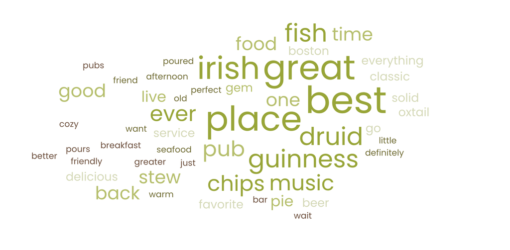

The establishment I've chosen for this Wildcard submission is the Druid Irish pub, located at Inman square in Cambridge. I promise not to make every Wildcard submission centered around something Irish but this is in my opinion the best Irish pub in Boston and a place I frequent regularily!

The wordcloud shows what you would probably expect when you think of an 'Irish' pub, although there are quite a few poor attempts at Irish pubs around Boston this one is far from it. Guiness, chips, fish & music are what comes to mind when glancing at the WordCloud, testament to the establishment is that I did try to find a couple of bad reviews to throw into the mix but they are few and far between. This place is held very dearly in the hearts of many who live in the Inman square/Cambridge area from all corners of the globe, made clear through the constant use of 'great', 'best', 'good' & 'gem'.

The food I can attest to is fantastic and the fish and chips is one of the best I've had since coming to America, although there were many glowing reviews for the beef stew which I am yet to try. The guinness I can attest to is also very good if being held to American standards but not the best in Boston in my opinion, the best pint can be found just 100 meters down the road at 'An Sibin', another renowned Irish pub.